# Recommender - Small Data

## 1 Data

Here is some simulated data on movie ratings: 4 users x 6 movies

```r
viewers = c('ViewerA','ViewerB','ViewerC','ViewerD')
movies = c('Beautiful_Mind','Goodwill_Hunting',
           'Remember_the_Titans','The_Rookie',
           'Jersey_Girl','Pursuit_of_Happyness')

data=data.frame()
set.seed(1)
for(viewer in viewers){
  random_number = round(runif(1,min = 1,max = 5))
  Viewer = rep(viewer,random_number)
  Movie = sample(movies,size = random_number,replace = F)
  Movie_rating = round(runif(random_number,min = 1,max = 5))
  data = rbind(data,data.frame(Viewer,Movie,Movie_rating))
}
data
```

| Viewer | Movie | Movie_rating |
| --- | --- | --- |
| ViewerA | The_Rookie | 2 |
| ViewerA | Beautiful_Mind | 5 |
| ViewerB | Remember_the_Titans | 3 |
| ViewerB | Goodwill_Hunting | 4 |
| ViewerB | Pursuit_of_Happyness | 3 |
| ViewerB | The_Rookie | 4 |
| ViewerB | Beautiful_Mind | 5 |
| ViewerC | Beautiful_Mind | 2 |
| ViewerC | Jersey_Girl | 3 |
| ViewerC | Pursuit_of_Happyness | 1 |

[output cut: 3 more lines]

[output not shown]

### 1.1 Restructure Data

Recast the data as realRatingMatrix

```r
library(recommenderlab)
data_matrix = as(data,Class = 'realRatingMatrix')
as(data_matrix,'matrix')
```

```
##         Beautiful_Mind Goodwill_Hunting Jersey_Girl Pursuit_of_Happyness
## ViewerA              5               NA          NA                   NA
## ViewerB              5                4          NA                    3
## ViewerC              2               NA           3                    1
## ViewerD             NA                3           3                    2
##         Remember_the_Titans The_Rookie
## ViewerA                  NA          2
## ViewerB                   3          4
## ViewerC                  NA         NA
## ViewerD                  NA         NA
```

## 2 Explore Data

What rating did viewer B (ViewerB) given to The Beautiful Mind (Beautiful_Mind)

```r
as(data_matrix,'matrix')['ViewerB','Beautiful_Mind']
```

```
## [1] 5
```

How many movies did viewer B (ViewerB) rate?

```r
Row_counts = rowCounts(data_matrix['ViewerB',])
Row_counts
```

```
## ViewerB
##       5
```

How many viewer ratings did The Beautiful Mind (Beautiful_Mind) receive?

```r
colCounts(data_matrix[,'Beautiful_Mind'])
```

```
## Beautiful_Mind
##              3
```

What is the most common rating in the dataset?

```r
table(getRatings(data_matrix))
```

```
##
## 1 2 3 4 5
## 1 3 5 2 2
```

What is the average rating of each movie?

```r
colMeans(data_matrix)
```

```
##       Beautiful_Mind     Goodwill_Hunting          Jersey_Girl
##                  4.0                  3.5                  3.0
## Pursuit_of_Happyness  Remember_the_Titans           The_Rookie
##                  2.0                  3.0                  3.0
```

For each movie, What is the sum of ratings?

```r
colSums(data_matrix)
```

```
##       Beautiful_Mind     Goodwill_Hunting          Jersey_Girl
##                   12                    7                    6
## Pursuit_of_Happyness  Remember_the_Titans           The_Rookie
##                    6                    3                    6
```

Rating patterns of viewer. What is average rating for each viewer? Do they vary?

```r
rowMeans(data_matrix)
```

```
##  ViewerA  ViewerB  ViewerC  ViewerD
## 3.500000 3.800000 2.000000 2.666667
```

```r
rowSds(data_matrix)
```

```
##   ViewerA   ViewerB   ViewerC   ViewerD
## 2.1213203 0.8366600 1.0000000 0.5773503
```

Since, users tend to vary in their pattern of evaluation (positivity bias, negativity bias, consistent ratings), it is a good practice to center (method = ‘center’) or standardize data by computing z score (method = ‘z-score’). White space in the image indicating NAs

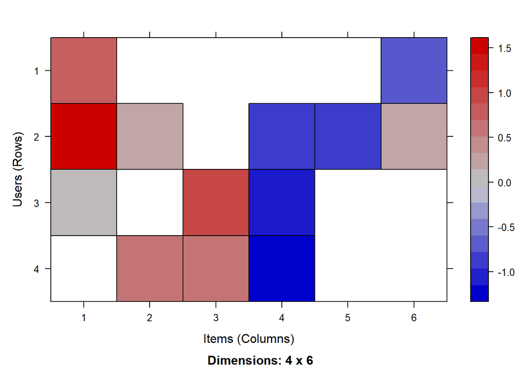

```r
data_matrix2 = normalize(data_matrix,method='Z-score')
image(data_matrix2)
```

Using the standardized user ratings generated above, assess the similarity between the first three viewers (ViewerA, ViewerB, ViewerC) over the first three items in the dataset using cosine similarity.

Which of the following pairs is most similar?

```r
similarity(data_matrix2[1:3,1:3],method='cosine')
```

```
##         ViewerA ViewerB
## ViewerB       1
## ViewerC       0       0
```

Using the standardized user ratings generated above, assess the similarity between the first three viewers (ViewerA, ViewerB, ViewerC) over all items in the dataset using cosine similarity.

Which of the following pairs is most similar?

```r
similarity(data_matrix2[1:3],method='cosine')
```

```
##           ViewerA   ViewerB
## ViewerB 0.5812382
## ViewerC 0.0000000 0.5547002
```

## 3 Non-Personalized Recommendation Systems

To keep things simple, in this illustration, we will not scale.

```r
recommenderRegistry$get_entry("POPULAR", type ="realRatingMatrix")
```

```
## Recommender method: POPULAR for realRatingMatrix
## Description: Recommender based on item popularity.
## Reference: NA
## Parameters:
##   normalize
## 1  "center"
##                                                      aggregationRatings
## 1 new("standardGeneric", .Data = function (x, na.rm = FALSE, dims = 1,
##                                                   aggregationPopularity
## 1 new("standardGeneric", .Data = function (x, na.rm = FALSE, dims = 1,
```

```r
recom = Recommender(data_matrix,method='POPULAR',
                    parameter = list(normalize=NULL))
pred = predict(recom,data_matrix)
as(pred,'matrix')
```

```
##         Beautiful_Mind Goodwill_Hunting Jersey_Girl Pursuit_of_Happyness
## ViewerA             NA              3.5           3                    2
## ViewerB             NA               NA           3                   NA
## ViewerC             NA              3.5          NA                   NA
## ViewerD              4               NA          NA                   NA
##         Remember_the_Titans The_Rookie
## ViewerA                   3         NA
## ViewerB                  NA         NA
## ViewerC                   3          3
## ViewerD                   3          3
```

You will note that the imputed ratings above are simply average ratings for each movie.

```r
colMeans(data_matrix)
```

```
##       Beautiful_Mind     Goodwill_Hunting          Jersey_Girl
##                  4.0                  3.5                  3.0
## Pursuit_of_Happyness  Remember_the_Titans           The_Rookie
##                  2.0                  3.0                  3.0
```

So, what is our top movie recommendation for each viewer? Obviously, the one with the highest rating!

```r
pred = predict(recom,data_matrix,n=1)
getList(pred)
```

```
## $ViewerA
## [1] "Goodwill_Hunting"
##
## $ViewerB
## [1] "Jersey_Girl"
##
## $ViewerC
## [1] "Goodwill_Hunting"
##
## $ViewerD
## [1] "Beautiful_Mind"
```

Can we recommend top 2 movies? (Note that if it may not be possible to recommend top 2 if there is only one unwatched movie)

```r
pred = predict(recom,data_matrix,n=2)
getList(pred)
```

```
## $ViewerA
## [1] "Goodwill_Hunting" "Jersey_Girl"
##
## $ViewerB
## [1] "Jersey_Girl"
##
## $ViewerC
## [1] "Goodwill_Hunting" "The_Rookie"
##
## $ViewerD
## [1] "Beautiful_Mind" "The_Rookie"
```

Which of the following is in the list of top 2 movies for viewer A?

```r
as(pred,'list')['ViewerA']
```

```
## $ViewerA
## [1] "Goodwill_Hunting" "Jersey_Girl"
```

What is the predicted rating for The Beautiful Mind by viewer A?

```r
pred = predict(recom,data_matrix,type='ratings')
as(pred,'matrix')['ViewerA','Beautiful_Mind']
```

```
## [1] NA
```

## 4 User-based Collaborative Filtering

Let’s use cosine similarity measure, set nearest neighbors to 3, and set normalize to NULL

```r
recommenderRegistry$get_entry(method='UBCF', type ='realRatingMatrix')
```

```
## Recommender method: UBCF for realRatingMatrix
## Description: Recommender based on user-based collaborative filtering.
## Reference: NA
## Parameters:
##     method nn sample weighted normalize min_matching_items min_predictive_items
## 1 "cosine" 25  FALSE     TRUE  "center"                  0                    0
```

```r
recom = Recommender(data_matrix,method='UBCF',
                    parameter=list(method='cosine',nn=3,normalize=NULL))
pred = predict(recom,data_matrix,type = 'ratings')
as(pred,'matrix')
```

```
##         Beautiful_Mind Goodwill_Hunting Jersey_Girl Pursuit_of_Happyness
## ViewerA             NA                4           3              1.97804
## ViewerB             NA               NA           3                   NA
## ViewerC             NA                4          NA                   NA
## ViewerD       3.525746               NA          NA                   NA
##         Remember_the_Titans The_Rookie
## ViewerA                   3         NA
## ViewerB                  NA         NA
## ViewerC                   3   2.998525
## ViewerD                   3   4.000000
```

Which movie to watch? Here is the top movie recommendation for each user.

```r
pred = predict(recom, data_matrix, n = 1)
getList(pred)
```

```
## $ViewerA
## [1] "Goodwill_Hunting"
##
## $ViewerB
## [1] "Jersey_Girl"
##
## $ViewerC
## [1] "Goodwill_Hunting"
##
## $ViewerD
## [1] "The_Rookie"
```

Now, let us examine how much each user will like the recommended movie.

```r
getRatings(pred)
```

```
## $ViewerA
## [1] 4
##
## $ViewerB
## [1] 3
##
## $ViewerC
## [1] 4
##
## $ViewerD
## [1] 4
```

A recommendation is only good if it is better than what the user would normally have watched. So, let us examine the average ratings for each movie watched by the four users.

```r
rowMeans(data_matrix)
```

```
##  ViewerA  ViewerB  ViewerC  ViewerD
## 3.500000 3.800000 2.000000 2.666667
```

Now, let us put it all together

```r
cbind(Recommended_Movie = getList(pred),
      UBCF_Predicted_Rating = getRatings(pred),
      Avg_User_Rating = rowMeans(data_matrix))
```

```
##         Recommended_Movie  UBCF_Predicted_Rating Avg_User_Rating
## ViewerA "Goodwill_Hunting" 4                     3.5
## ViewerB "Jersey_Girl"      3                     3.8
## ViewerC "Goodwill_Hunting" 4                     2
## ViewerD "The_Rookie"       4                     2.666667
```

## 5 Item-based Collaborative Filtering

```r
recommenderRegistry$get_entry(method='IBCF', type ='realRatingMatrix')
```

```
## Recommender method: IBCF for realRatingMatrix
## Description: Recommender based on item-based collaborative filtering.
## Reference: NA
## Parameters:
##    k   method normalize normalize_sim_matrix alpha na_as_zero
## 1 30 "Cosine"  "center"                FALSE   0.5      FALSE
```

```r
recom = Recommender(data_matrix,method='IBCF',
                    parameter=list(method='cosine',k=3,normalize=NULL))
pred = predict(recom,data_matrix,type = 'ratings')
as(pred,'matrix')
```

```
##         Beautiful_Mind Goodwill_Hunting Jersey_Girl Pursuit_of_Happyness
## ViewerA             NA                2    5.000000                    2
## ViewerB             NA               NA    4.017403                   NA
## ViewerC             NA                3          NA                   NA
## ViewerD              3               NA          NA                   NA
##         Remember_the_Titans The_Rookie
## ViewerA                 2.0         NA
## ViewerB                  NA         NA
## ViewerC                 1.0        1.0
## ViewerD                 2.5        2.5
```

Which movie to watch? Here is the top movie recommendation for each user.

```r
pred = predict(recom, data_matrix, n = 1)
getList(pred)
```

```
## $ViewerA
## [1] "Jersey_Girl"
##
## $ViewerB
## [1] "Jersey_Girl"
##
## $ViewerC
## [1] "Goodwill_Hunting"
##
## $ViewerD
## [1] "Beautiful_Mind"
```

Now, let us examine how much each user will like the recommended movie.

```r
getRatings(pred)
```

```
## $ViewerA
## [1] 5
##
## $ViewerB
## [1] 4.017403
##
## $ViewerC
## [1] 3
##
## $ViewerD
## [1] 3
```

Finally, as noted above, a recommendation is only good if it is better than what the user would normally have watched. So, let us examine the average ratings for each movie watched by the four users.

```r
cbind(Recommended_Movie = getList(pred),
      IBCF_Predicted_Rating = getRatings(pred),
      Avg_User_Rating = rowMeans(data_matrix))
```

```
##         Recommended_Movie  IBCF_Predicted_Rating Avg_User_Rating
## ViewerA "Jersey_Girl"      5                     3.5
## ViewerB "Jersey_Girl"      4.017403              3.8
## ViewerC "Goodwill_Hunting" 3                     2
## ViewerD "Beautiful_Mind"   3                     2.666667
```

## 6 Hybrid Recommender

Setup the recommenders

```r
rec_pop = Recommender(data_matrix, "POPULAR",
                      parameter = list(normalize=NULL))
rec_ub = Recommender(data_matrix,'UBCF',
                     parameter=list(method='Cosine',nn=3,normalize=NULL))
rec_ib =  Recommender(data_matrix, "IBCF",
                      parameter = list(method='Cosine',k=3,normalize=NULL))
#Save recommender models for later so we do not have to rebuild them
save(rec_pop, rec_ub, rec_ib, file = "models.rda")
# Load models
load("models.rda")
```

Create predictions. Now, let us examine predicted ratings using each recommender but only for the fourth user, Viewer D

```r
pred_pop = predict(rec_pop, data_matrix[4,], type = "ratings")
as(pred_pop,'list')
```

```
## $ViewerD
##      Beautiful_Mind Remember_the_Titans          The_Rookie
##                   4                   3                   3
```

```r
pred_ub  = predict(rec_ub, data_matrix[4,], type = "ratings")
as(pred_ub,'list')
```

```
## $ViewerD
##      Beautiful_Mind Remember_the_Titans          The_Rookie
##            3.525746            3.000000            4.000000
```

```r
pred_ib  = predict(rec_ib, data_matrix[4,], type = "ratings")
as(pred_ib, 'list')
```

```
## $ViewerD
##      Beautiful_Mind Remember_the_Titans          The_Rookie
##                 3.0                 2.5                 2.5
```

Aggregate predictions

```r
pred_hybrid = rbind(
  as(pred_pop, 'matrix'),
  as(pred_ub,'matrix'),
  as(pred_ib, 'matrix'))
pred_hybrid
```

```
##         Beautiful_Mind Goodwill_Hunting Jersey_Girl Pursuit_of_Happyness
## ViewerD       4.000000               NA          NA                   NA
## ViewerD       3.525746               NA          NA                   NA
## ViewerD       3.000000               NA          NA                   NA
##         Remember_the_Titans The_Rookie
## ViewerD                 3.0        3.0
## ViewerD                 3.0        4.0
## ViewerD                 2.5        2.5
```

```r
pred_hybrid = colMeans(pred_hybrid)
pred_hybrid
```

```
##       Beautiful_Mind     Goodwill_Hunting          Jersey_Girl
##             3.508582                   NA                   NA
## Pursuit_of_Happyness  Remember_the_Titans           The_Rookie
##                   NA             2.833333             3.166667
```

Create a top-N list from the aggregated ratings

```r
pred <- getTopNLists(as(rbind(pred_hybrid), "realRatingMatrix"))
as(pred, 'list')
```

```
## $pred_hybrid
## [1] "Beautiful_Mind"      "The_Rookie"          "Remember_the_Titans"
```

Compare with the results by the individual recommenders

```r
as(getTopNLists(pred_pop), 'list')
```

```
## $ViewerD
## [1] "Beautiful_Mind"      "Remember_the_Titans" "The_Rookie"
```

```r
as(getTopNLists(pred_ib), 'list')
```

```
## $ViewerD
## [1] "Beautiful_Mind"      "Remember_the_Titans" "The_Rookie"
```

```r
as(getTopNLists(pred_ub), 'list')
```

```
## $ViewerD
## [1] "The_Rookie"          "Beautiful_Mind"      "Remember_the_Titans"
```

This file was generated using R Version 4.1.2